# Cats Cradle Spatial Vignette

## Introduction

### Cats Cradle: cells and genes

Cats Cradle exploits the duality between cells and genes. A standard Seurat analysis is based on a genes-by-cells matrix, that is, a matrix whose rows correspond to genes, whose columns correspond to cells and whose entries give the expression of each gene in each cell. Typically, one clusters the cells and displays the resulting cell types on a dimension reduction such as UMAP.

Cats Cradle exploits the duality by transposing the matrix so that rows correspond to cells and columns correspond to genes. This allows one to cluster the genes and display the resulting gene types on a UMAP of genes.

### Spatial Cats Cradle: neighbourhoods and cell types

Adding spatial information to this mix allows an additional level of analysis. Here the role of individual cells is played by sets of cells (i.e., spatial neighbourhoods) and the role of genes is played by types of cells in each neighbourhood. (We’ll say more about neighbourhoods in a moment.) The underlying data is now a matrix whose rows correspond to cell types and whose columns correspond to neighbourhoods. Each entry gives the number of cells of a given cell type in each neighbourhood. With poetic license, we can say that a neighbourhood “expresses” cell types.

One can then cluster neighbourhoods on the basis of the cell types. That is, neighbourhoods are clustered into types based on the mix of cell types that they contain. One also has a UMAP of neighbourhoods based on their cell type mix.

Exploiting the duality between neighbourhoods and cell types, we can also produce a Seurat object whose rows are neighbourhoods and whose columns columns are cell types. This allows one to cluster the cell types. Cell types then cluster together if they associated into the same sorts of neighbourhoods.

## Neighbourhoods

A neighbourhood is simply a set of cells. For our puposes, we will take it to be a spatially contiguous set of cells, though mathematically, this is not necessary. Here we exhibit several ways of aggregating cells into neigbourhoods based on their spatial locations.

First load the spatial data:

```r
#xenium.obj = read.rds("/path/to/xenium.obj.rds")

load("../data/smallXenium.rda")
```

To illustrate this concept we use a subset of a xenium data set that profiles the mouse the mouse hippocampus available from 10x genomics (https://www.10xgenomics.com/datasets/fresh-frozen-mouse-brain-for-xenium-explorer-demo-1-standard)

We will now visualise this dataset coloured by cell population (louvain cluster)

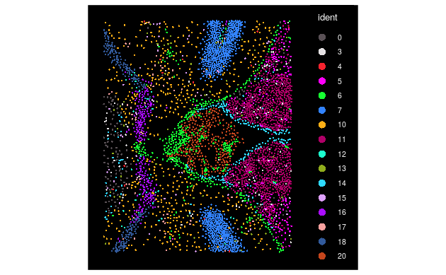

```r
ImageDimPlot(smallXenium, cols = "polychrome", size = 1)
```

To calculate neighbourhoods we will extract centroids for each cell.

```r
centroids = GetTissueCoordinates(smallXenium)
rownames(centroids) = centroids$cell
```

Additionally we will extract information on celltype or cluster.

```r
clusters = smallXenium@active.ident
```

### Nearest neighbour graphs:

The centroids of the cells are given as points in the plane. Delaunay triangulation discovers and optimal way of connecting each of these points to its neighbors. For each cell in the spatial Seurat object the following discovers its neighbours based on this Delaunay triangulation:

Compute spatial neighbours based on Delaunay triangulation.

```r
delaunayNeighbours = computeNeighboursDelaunay(centroids)
```

Another way to compute the neighbours of a given cell is to simply ask for all the cells within a fixed (Euclidean) distance of that cell:

```r
euclideanNeighbours = computeNeighboursEuclidean(centroids,
threshold=20)
```

Notice that when using this spatial nearest neighbours method each neighbourhood corresponds to an individual cell - it is the neighbourhood around that cell. Also note that these neighbourhoods are not disjoint. We speculate that Delaunay neighbourhoods are more appropriate for investigating cell-cell interactions while Euclidean neighbourhoods are more appropriate for investigating diffusible ligands.

### nth degree neighbour graphs

Given any graph calculated to report neighbours of degree one, it is now possible to expand this to neighbours up to a higher degree (n).

```r
expandedNeighbours = expandNeighbourhoods(delaunayNeighbours, 4)
```

```
[1] 2
[1] 3
[1] 4
```

This returns a list of neighbour graphs where the first item (expandedNeighbours[[1]]) is the graph of 1st degree neighbours, the second item the graph of 2nd degree neighbours e.t.c.

To obtain a graph that contains the all neighbours up to and including degree 4 (for example) we can simply rbind the individual neighbour graphs.

```r
expandedNeighboursFourth = as.data.frame(rbind(expandedNeighbours[[1]],
                                 expandedNeighbours[[2]],
                                 expandedNeighbours[[3]],
                                 expandedNeighbours[[4]]))
```

## Calculation of neighbourhood celltype composition

Given any of the spatial graphs describing neighbourhoods calculated above, we can now calculate the cell type composition of neighbourhoods.

```r
neighbourhoodByCTMatrix = computeNeighbourhoodByCTMatrix(delaunayNeighbours,
                                                        clusters)
```

In the resulting matrix neighbourhoods are rows and cell types are columns. The values in the matrix indicate the number of cells of a given type within a neighbourhood.

Let’s do the same for our expanded neighbourhoods.

```r
neighbourhoodByCTMatrixExpanded = computeNeighbourhoodByCTMatrix(expandedNeighboursFourth,
                                                        clusters)
```

## Analysis of contact based interactions between cell types

We can go on to calculate a matrix which gives the fraction of contacts cells of a given type make with cells of another cell type.

```r
cellTypesPerCellTypeMatrix = computeCellTypesPerCellTypeMatrix(neighbourhoodByCTMatrix,clusters)
```

We can then display this as a force directed graph. Here we choose only to display contact based interactions that constitute at least 5% of a cell type’s interactions. Of note, this graph is directed as, for example, 50% of cell type A’s interactions might be with cell type B, but only 5% of cell type B’s contacts might be with cell type A.

```
IGRAPH 1212cf1 DNW- 16 55 --
+ attr: coords (g/n), name (v/c), color (v/c), weight (e/n), width (e/n)
+ edges from 1212cf1 (vertex names):
 [1] 0 ->3  0 ->5  0 ->10 0 ->11 0 ->13 0 ->14 3 ->0  3 ->5  3 ->10 3 ->11 4 ->0  4 ->3  4 ->5  4 ->6  4 ->7  4 ->10 4 ->11 4 ->14 4 ->17 4 ->20 5 ->3  5 ->6  5 ->11 6 ->10
[25] 6 ->20 10->6  10->7  10->17 11->5  12->7  12->10 12->16 12->18 13->0  13->3  13->6  13->7  13->10 13->11 14->0  14->6  14->11 14->20 15->0  15->7  15->10 15->11 16->10
[49] 16->18 17->7  17->10 17->16 18->10 18->16 20->6
```

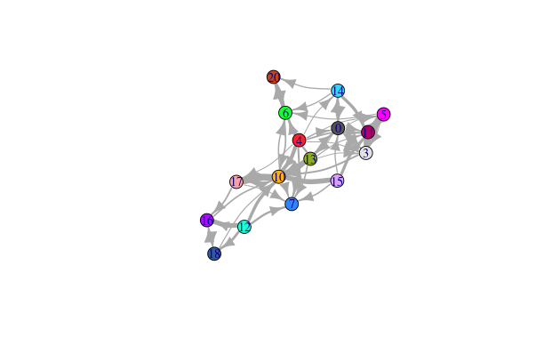

```r
colors = DiscretePalette(length(levels(clusters)), palette = "polychrome")
names(colors) = levels(clusters)
cellTypesPerCellTypeGraphFromMatrix(cellTypesPerCellTypeMatrix, minWeight = 0.05, colors = colors)
```

Let’s do the same for our expanded nighbourhoods.

```
IGRAPH d11876a DNW- 16 62 --
+ attr: coords (g/n), name (v/c), color (v/c), weight (e/n), width (e/n)
+ edges from d11876a (vertex names):
 [1] 0 ->3  0 ->10 0 ->11 0 ->14 3 ->0  3 ->5  3 ->6  3 ->10 3 ->11 3 ->14 4 ->0  4 ->5  4 ->6  4 ->7  4 ->10 4 ->11 4 ->14 4 ->20 5 ->6  5 ->11 6 ->10 6 ->11 6 ->20 7 ->10
[25] 10->6  10->7  10->16 10->18 11->5  11->14 12->7  12->10 12->16 12->18 13->0  13->5  13->6  13->7  13->10 13->11 14->0  14->6  14->10 14->11 14->20 15->0  15->6  15->7
[49] 15->10 15->11 15->16 16->10 16->18 17->6  17->7  17->10 17->16 17->18 18->10 18->16 20->6  20->14
```

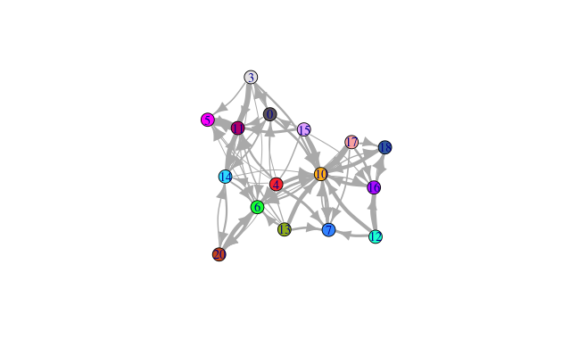

```r
cellTypesPerCellTypeMatrixExpanded = computeCellTypesPerCellTypeMatrix(neighbourhoodByCTMatrixExpanded,clusters)

cellTypesPerCellTypeGraphFromMatrix(cellTypesPerCellTypeMatrixExpanded, minWeight = 0.05, colors = colors)
```

## Analysis of neighbourhoods based on cell type composition

We can now perform dimensionality reduction and clustering based on neighbourhood composition. As the dimensionality of the feature space is relatively low (number of cell types) we calculate the UMAP using features rather than PCs.

```r
neighbourhoodSeurat = computeNeighbourhoodByCTSeurat(neighbourhoodByCTMatrix)
```

Add cell type information to the neighbourhoodSeurat object.

```r
neighbourhoodSeurat$cellType = as.character(clusters)
```

Visualise neighbourhood clusters.

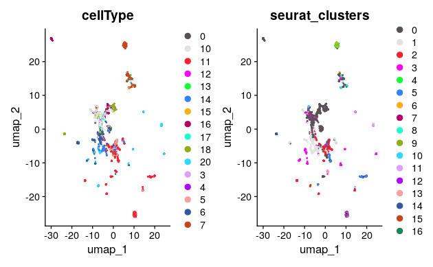

```r
DimPlot(neighbourhoodSeurat, group.by = c("cellType", "seurat_clusters"), cols = "polychrome", reduction = "umap")
```

We can now add information on neighbourhood clusters to our original xenium object and visualise these on the tissue.

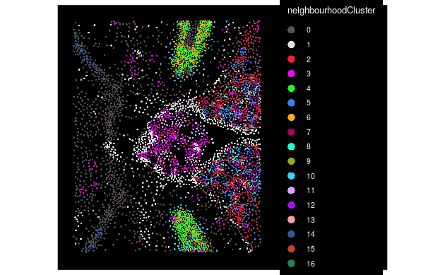

```r
smallXenium$neighbourhoodCluster = neighbourhoodSeurat@active.ident
ImageDimPlot(smallXenium, group.by = "neighbourhoodCluster", size = 1, cols = "polychrome")
```

Lets try the same thing with our expanded neighbourhoods up to degree 4.

```r
neighbourhoodSeuratExpanded = computeNeighbourhoodByCTSeurat(neighbourhoodByCTMatrixExpanded)
```

[output not shown]

```
Modularity Optimizer version 1.3.0 by Ludo Waltman and Nees Jan van Eck

Number of nodes: 4261
Number of edges: 105168

Running Louvain algorithm...
```

```
Maximum modularity in 10 random starts: 0.9694
Number of communities: 8
Elapsed time: 0 seconds
```

Add cell type information to the neighbourhoodSeurat object.

```r
neighbourhoodSeuratExpanded$cellType = as.character(clusters)
```

Visualise neighbourhood clusters.

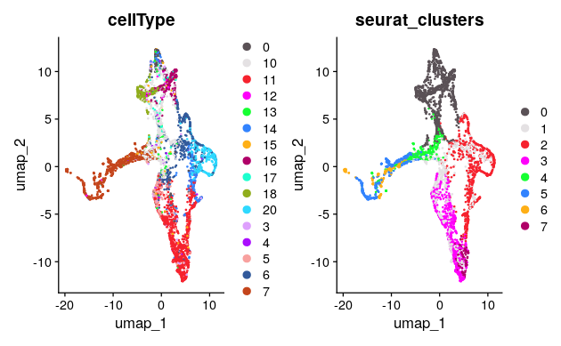

```r
DimPlot(neighbourhoodSeuratExpanded, group.by = c("cellType", "seurat_clusters"), cols = "polychrome", reduction = "umap")
```

We can now add information on neighbourhood clusters to our original xenium object and visualise these on the tissue.

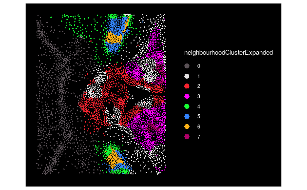

```r
smallXenium$neighbourhoodClusterExpanded =
  neighbourhoodSeuratExpanded@active.ident
ImageDimPlot(smallXenium, group.by = c("neighbourhoodClusterExpanded"),
             size = 1, cols = "polychrome")
```

Here we retrieve fewer clusters, and these describe tissue architecture rather than small variations in cellular niche.

We leave it to the user to decide which approach is most applicable to the biological question at hand.

## Relating cell type clusters to neighbourhood clusters

We can now ask how clusters defined transcriptomically (cell type) relate to those defined based on neighbourhoods (cell niche).

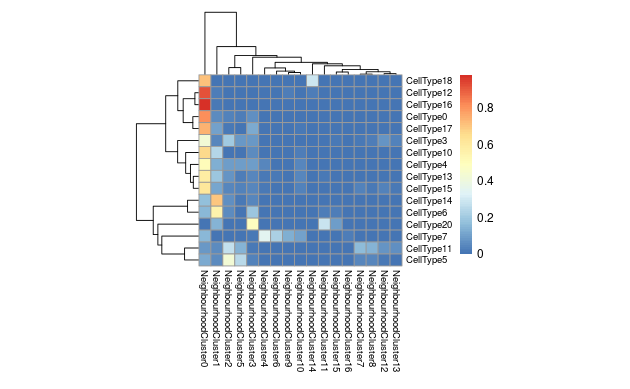

```r
CTbyNeighbourhoodCluster = table(neighbourhoodSeurat$cellType,neighbourhoodSeurat@active.ident)
CTbyNeighbourhoodCluster = CTbyNeighbourhoodCluster/rowSums(CTbyNeighbourhoodCluster)

rownames(CTbyNeighbourhoodCluster) = paste0("CellType",rownames(CTbyNeighbourhoodCluster))
colnames(CTbyNeighbourhoodCluster) = paste0("NeighbourhoodCluster",colnames(CTbyNeighbourhoodCluster))

pheatmap(CTbyNeighbourhoodCluster,
      fontsize_row=8,
      fontsize_col=8,
      cellheight=10,
      cellwidth=10)
```

```r
sankeyFromMatrix(CTbyNeighbourhoodCluster)
```

[interactive chart not shown]

This allows us to see which cell types share the same niche (neighbourhood clusters). Let’s also perform this analysis using the expanded neighbourhoods.

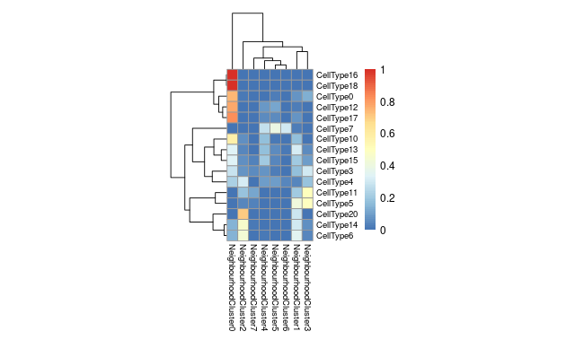

```r
CTbyNeighbourhoodClusterExpanded = table(neighbourhoodSeuratExpanded$cellType,
                                      neighbourhoodSeuratExpanded@active.ident)
CTbyNeighbourhoodClusterExpanded =
  CTbyNeighbourhoodClusterExpanded/rowSums(CTbyNeighbourhoodClusterExpanded)

rownames(CTbyNeighbourhoodClusterExpanded) = paste0("CellType",
                                    rownames(CTbyNeighbourhoodClusterExpanded))
colnames(CTbyNeighbourhoodClusterExpanded) = paste0("NeighbourhoodCluster",
                                   colnames(CTbyNeighbourhoodClusterExpanded))

pheatmap(CTbyNeighbourhoodClusterExpanded,
      fontsize_row=8,
      fontsize_col=8,
      cellheight=10,
      cellwidth=10)
```

```r
sankeyFromMatrix(CTbyNeighbourhoodClusterExpanded)
```

[interactive chart not shown]

## Analysing cell types based on their neighbourhoods

Now we perform dimensionality and clustering of cell types, based on the neighbourhoods they are found in. Note that this is based on the transpose of the matrix used in the previous section.

First we create a seurat object for a cell type by neighbourhood matrix (the transposed neighbourhoodByCTMatrix). Here we have a large feature space (numbers of cells) however low number of observations (number of cell types). Therefore we compute the UMAP using PCs however due to the low number of observations we need to set a lower value for n.neighbours.

```r
neighbourhoodSeuratPrime =
  computeNeighbourhoodByCTSeurat(t(neighbourhoodByCTMatrix), npcs = 10,
                                 transpose = T, resolution = 1, n.neighbors = 5)
```

[output not shown]

```
Modularity Optimizer version 1.3.0 by Ludo Waltman and Nees Jan van Eck

Number of nodes: 16
Number of edges: 120

Running Louvain algorithm...
```

```
Maximum modularity in 10 random starts: 0.0000
Number of communities: 1
Elapsed time: 0 seconds
```

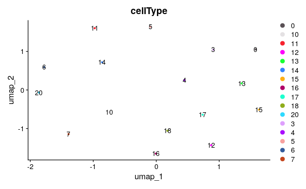

```r
neighbourhoodSeuratPrime$cellType = colnames(neighbourhoodSeuratPrime)

DimPlot(neighbourhoodSeuratPrime, group.by = "cellType", cols = "polychrome",
        reduction = "umap", label = T)
```

Let’s perform the same analysis using the expanded neighbourhoods.

```r
neighbourhoodSeuratPrimeExpanded =
  computeNeighbourhoodByCTSeurat(t(neighbourhoodByCTMatrixExpanded), npcs = 10,
                                 transpose = T, resolution = 1, n.neighbors = 5)
```

[output not shown]

```
Modularity Optimizer version 1.3.0 by Ludo Waltman and Nees Jan van Eck

Number of nodes: 16
Number of edges: 120

Running Louvain algorithm...
```

```
Maximum modularity in 10 random starts: 0.0000
Number of communities: 1
Elapsed time: 0 seconds
```

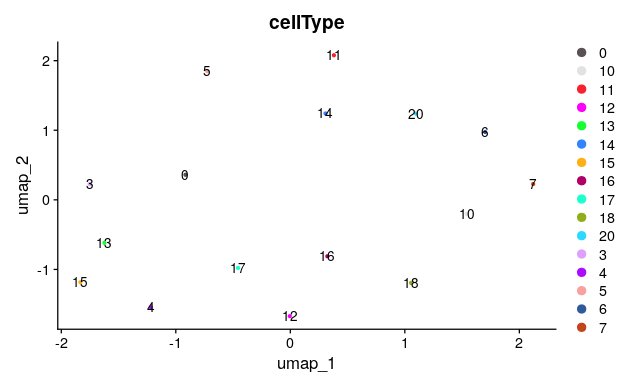

```r
neighbourhoodSeuratPrimeExpanded$cellType = colnames(neighbourhoodSeuratPrimeExpanded)

DimPlot(neighbourhoodSeuratPrimeExpanded, group.by = "cellType", cols = "polychrome",
        reduction = "umap", label = T)
```

We can also compute a graph embedding.

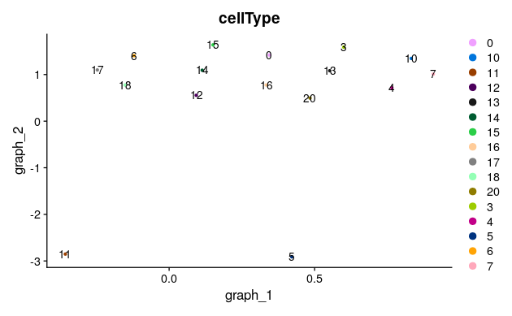

```r
neighbourhoodSeuratPrimeExpanded = computeGraphEmbedding(neighbourhoodSeuratPrimeExpanded)
DimPlot(neighbourhoodSeuratPrimeExpanded,group.by = "cellType", cols = "alphabet", reduction = "graph", label = T)
```

We achieve only one cluster using the louvain algorithm. Let’s try hierachical clustering.

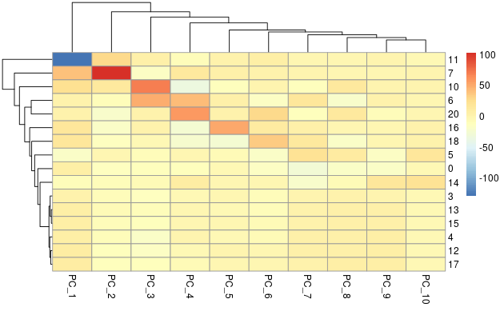

```r
library(pheatmap)

pcaExpanded = Embeddings(neighbourhoodSeuratPrimeExpanded, reduction = "pca")
resExpanded = pheatmap(pcaExpanded)
```

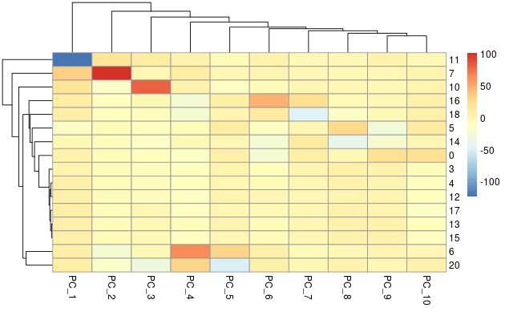

```r
pca= Embeddings(neighbourhoodSeuratPrime, reduction = "pca")
res = pheatmap(pca)
```

Here we decide to cut the tree at the correct level to form 11 clusters.

```r
CTclust = cutree(res$tree_row, k = 11)
neighbourhoodSeuratPrime$seurat_clusters = factor(CTclust)
```

Let’s investigate how neighbourhood clusters relate to cell type clusters.

```r
averageExpMatrix = getAverageExpressionMatrix(neighbourhoodSeurat,neighbourhoodSeuratPrime)
averageExpMatrix = tagRowAndColNames(averageExpMatrix,
                                     ccTag='neighbourhoodClusters_',
                                     gcTag='cellTypeClusters_')
pheatmap(averageExpMatrix,
      fontsize_row=8,
      fontsize_col=8,
      cellheight=10,
      cellwidth=10)
```

[output not shown]

```r
sankeyFromMatrix(averageExpMatrix)
```

[interactive chart not shown]